# Housing Data Modeling

Scott Breitbach

11/14/2021

## Load Dataframes

```r
# Entire Dataset with Ordinal Variables converted
dfOrd <- read.csv("data/dfTrainC.csv")      # 1460 x  81
# Entire Dataset with dummy variables created
dfAn <- read.csv("data/dfAnalysis.csv")     # 1 1460 x 257 (with all dummies)

## FEATURE SELECTED DATA SUBSETS:
# Variables that highly correlate (>0.5) w/SalePrice
dfCorrSP <- read.csv("data/dfTrain1.csv")   # 2 1460 x  16 (correlate with SalePrice)
# Variables with high F-statistic value (top 30)
dfFstat <- read.csv("data/featFstatistic.csv") # 4 1460 x 31 (top F stat features)
# Variables with high LightBGM value (top 30)
dfLBGM <- read.csv("data/featLightBGM.csv")    # 5 1460 x 31 (top LightBGM features)
# Variables with high Logistic Regression value (top 30)
dfLogReg <- read.csv("data/featLogisticRegression.csv") # 6 1460 x 31 (logreg feat)
# Variables with high Mutual Information value (top 30)
dfMInf <- read.csv("data/featMutualInformation.csv")    # 7 1460 x 31 (mutualinf feat)
# Overall combined top variables from feature selections (top 30)
dfOverall <- read.csv("data/featOverall.csv")  # 8 1460 x 31 (top overall features)
```

# Linear Regression Modeling

```r
# Get summary of model for each data set
lmOrd = lm(formula = SalePrice~., data = dfOrd)
lmAn = lm(formula = SalePrice~., data = dfAn)
lmCorrSP = lm(formula = SalePrice~., data = dfCorrSP)
lmFstat = lm(formula = SalePrice~., data = dfFstat)
lmLBGM = lm(formula = SalePrice~., data = dfLBGM)
lmLogReg = lm(formula = SalePrice~., data = dfLogReg)
lmMInf = lm(formula = SalePrice~., data = dfMInf)
lmOverall = lm(formula = SalePrice~., data = dfOverall)

# Summary of one model
summary(lmFstat)
```

```
##
## Call:
## lm(formula = SalePrice ~ ., data = dfFstat)
##
## Residuals:
##     Min      1Q  Median      3Q     Max
## -380441  -17720     182   16110  266365
##
## Coefficients:
##                         Estimate Std. Error t value Pr(>|t|)
## (Intercept)           -1.259e+05  6.779e+03 -18.570  < 2e-16 ***
## SaleType_Con           3.943e+04  2.519e+04   1.566 0.117646
## Condition2_RRAn       -1.821e+04  3.478e+04  -0.523 0.600732
## Heating_Floor          3.332e+04  3.502e+04   0.952 0.341440
## Exterior2nd_Other      4.943e+04  3.493e+04   1.415 0.157327
## SaleCondition_Alloca   7.366e+03  1.018e+04   0.724 0.469303
## LotArea                9.266e-01  9.547e-02   9.706  < 2e-16 ***
## Neighborhood_Veenker   3.028e+04  1.082e+04   2.799 0.005193 **
## OverallQual            1.450e+04  1.219e+03  11.892  < 2e-16 ***
## Neighborhood_NoRidge   5.504e+04  5.967e+03   9.224  < 2e-16 ***
## Neighborhood_NridgHt   4.006e+04  4.581e+03   8.746  < 2e-16 ***
## Heating_Grav          -2.521e+03  1.333e+04  -0.189 0.850045
## SaleCondition_Partial -5.575e+03  2.013e+04  -0.277 0.781838
## SaleType_New           2.542e+04  2.042e+04   1.245 0.213361
## ExterQual              9.285e+03  2.693e+03   3.448 0.000582 ***
## GarageCars             1.259e+04  1.614e+03   7.798 1.20e-14 ***
## Exterior2nd_CmentBd    1.480e+04  4.768e+03   3.105 0.001942 **
## KitchenQual            1.407e+04  2.117e+03   6.647 4.23e-11 ***
## BsmtQual               8.715e+03  1.401e+03   6.223 6.40e-10 ***
## Condition2_PosN       -1.663e+05  2.532e+04  -6.568 7.12e-11 ***
## GrLivArea              4.551e+01  2.337e+00  19.474  < 2e-16 ***
## ---
## Signif. codes:  0 '***' 0.001 '**' 0.01 '*' 0.05 '.' 0.1 ' ' 1
##
## Residual standard error: 34740 on 1439 degrees of freedom
## Multiple R-squared:  0.8114, Adjusted R-squared:  0.8088
## F-statistic: 309.6 on 20 and 1439 DF,  p-value: < 2.2e-16
```

## Compare Linear Regression Models

[Source](https://cran.r-project.org/web/packages/performance/performance.pdf)

```r
# Load libraries
library(performance)

# Compare models
compare_performance(lmOrd, lmAn, lmCorrSP, lmFstat,
                    lmLBGM, lmLogReg, lmMInf, lmOverall)
```

```
## # Comparison of Model Performance Indices
##
## Name      | Model |       AIC |  AIC_wt |       BIC |  BIC_wt |    R2 | R2 (adj.) |      RMSE |     Sigma
## ---------------------------------------------------------------------------------------------------------
## lmOrd     |    lm | 33825.292 |   0.500 | 34908.961 | < 0.001 | 0.919 |     0.906 | 22576.270 | 24340.741
## lmAn      |    lm | 33825.292 |   0.500 | 34908.961 | < 0.001 | 0.919 |     0.906 | 22576.270 | 24340.741
## lmCorrSP  |    lm | 34833.905 | < 0.001 | 34923.770 | < 0.001 | 0.791 |     0.789 | 36273.295 | 36473.701
## lmFstat   |    lm | 34696.338 | < 0.001 | 34812.634 |   0.952 | 0.811 |     0.809 | 34485.714 | 34736.436
## lmLBGM    |    lm | 35085.861 | < 0.001 | 35196.871 | < 0.001 | 0.753 |     0.750 | 39433.996 | 39706.899
## lmLogReg  |    lm | 35790.347 | < 0.001 | 35906.643 | < 0.001 | 0.601 |     0.596 | 50159.396 | 50524.070
## lmMInf    |    lm | 36919.794 | < 0.001 | 37036.090 | < 0.001 | 0.135 |     0.123 | 73847.551 | 74384.445
## lmOverall |    lm | 34702.326 | < 0.001 | 34818.622 |   0.048 | 0.811 |     0.808 | 34556.504 | 34807.740
```

Using the entire data set provides the same results, whether or not dummy variables are included. Barring use of the entire data set for modeling, feature selection by F-statistic provides the lowest AIC and highest r-squared, followed closely by the Overall selected features and the highly correlated.

## Check Model

```r
# Check Collinearity of Model Variables
check_collinearity(lmFstat)
```

```
## # Check for Multicollinearity
##
## Low Correlation
##
##                  Term  VIF Increased SE Tolerance
##          SaleType_Con 1.05         1.02      0.95
##       Condition2_RRAn 1.00         1.00      1.00
##         Heating_Floor 1.02         1.01      0.98
##     Exterior2nd_Other 1.01         1.01      0.99
##  SaleCondition_Alloca 1.02         1.01      0.98
##               LotArea 1.10         1.05      0.91
##  Neighborhood_Veenker 1.06         1.03      0.94
##           OverallQual 3.44         1.85      0.29
##  Neighborhood_NoRidge 1.18         1.08      0.85
##  Neighborhood_NridgHt 1.27         1.13      0.79
##          Heating_Grav 1.03         1.01      0.97
##             ExterQual 2.89         1.70      0.35
##            GarageCars 1.76         1.33      0.57
##   Exterior2nd_CmentBd 1.08         1.04      0.92
##           KitchenQual 2.39         1.55      0.42
##              BsmtQual 1.82         1.35      0.55
##       Condition2_PosN 1.06         1.03      0.94
##             GrLivArea 1.82         1.35      0.55
##
## High Correlation
##
##                   Term   VIF Increased SE Tolerance
##  SaleCondition_Partial 38.38         6.19      0.03
##           SaleType_New 38.63         6.22      0.03
```

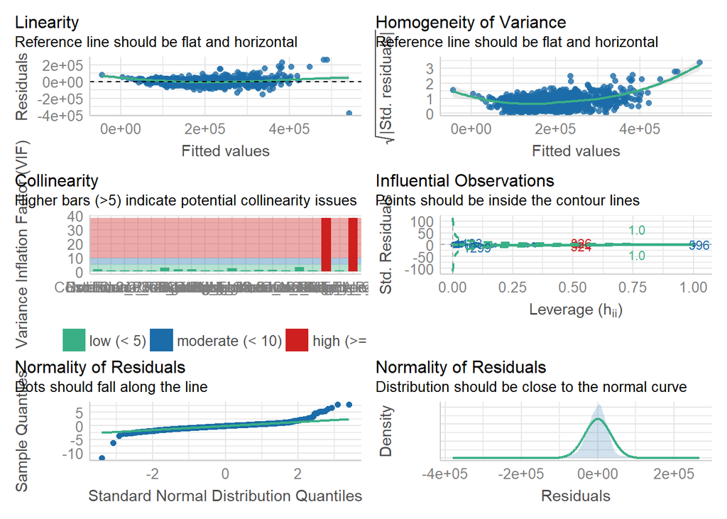

```r
# Visualization of multiple model checks
check_model(lmFstat)
```

The dummy variables `SaleCondition_Partial` and `SaleType_New` show a high degree of correlation and one of these should probably be removed.

## Check Accuracy of Models

```r
# Only included feature-selected data sets due to size
accCorrSP <- performance_accuracy(lmCorrSP, method = c("cv", "boot"), k = 5, n = 1000)
print("Accuracy lmCorrSP: ")
```

```
## [1] "Accuracy lmCorrSP: "
```

```r
accCorrSP$Accuracy
```

```
## [1] 0.8858577
```

```r
accFstat <- performance_accuracy(lmFstat, method = c("cv", "boot"), k = 5, n = 1000)
print("Accuracy lmFstat: ")
```

```
## [1] "Accuracy lmFstat: "
```

```r
accFstat$Accuracy
```

```
## [1] 0.8880362
```

```r
accLBGM <- performance_accuracy(lmLBGM, method = c("cv", "boot"), k = 5, n = 1000)
print("Accuracy lmLBGM: ")
```

```
## [1] "Accuracy lmLBGM: "
```

```r
accLBGM$Accuracy
```

```
## [1] 0.8648927
```

```r
accLogReg <- performance_accuracy(lmLogReg, method = c("cv", "boot"), k = 5, n = 1000)
print("Accuracy lmLogReg: ")
```

```
## [1] "Accuracy lmLogReg: "
```

```r
accLogReg$Accuracy
```

```
## [1] 0.7671006
```

```r
accMInf <- performance_accuracy(lmMInf, method = c("cv", "boot"), k = 5, n = 1000)
print("Accuracy lmMInf: ")
```

```
## [1] "Accuracy lmMInf: "
```

```r
accMInf$Accuracy
```

```
## [1] 0.3244102
```

```r
accOverall <- performance_accuracy(lmOverall, method = c("cv", "boot"), k = 5, n = 1000)
print("Accuracy lmOverall: ")
```

```
## [1] "Accuracy lmOverall: "
```

```r
accOverall$Accuracy
```

```
## [1] 0.8919855
```

The Overall features data set shows the best accuracy here at 89%, narrowly beating out F-statistic and Correlation as feature selection methods for linear regression modeling.

## Hosmer-Lemeshow Goodness-of-Fit Test

```r
# Requires glm instead of lm
glmOverall = glm(formula = SalePrice~., data = dfOverall)
performance_hosmer(glmOverall)
```

```
## # Hosmer-Lemeshow Goodness-of-Fit Test
##
##   Chi-squared: -3.322
##            df:  8
##       p-value:  1.000
```

```
## Summary: model seems to fit well.
```

Model seems to fit well.

# Decision Trees

[Source](https://www.datacamp.com/community/tutorials/decision-trees-R)

## Random Forest

```r
# Load Libraries
library(randomForest)
# Set up training set
train.overall = sample(1:nrow(dfOverall), 1060)

# Set up random forest model using training subset
rf.overall = randomForest(SalePrice~., data = dfOverall, subset = train.overall)
rf.overall
```

```
##
## Call:
##  randomForest(formula = SalePrice ~ ., data = dfOverall, subset = train.overall)
##                Type of random forest: regression
##                      Number of trees: 500
## No. of variables tried at each split: 6
##
##           Mean of squared residuals: 1139528567
##                     % Var explained: 82.21
```

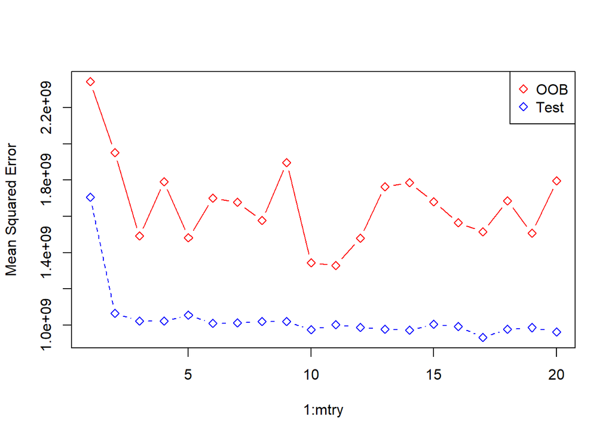

```r
## TUNING
# Set up error variables
oob.err = double(20)
test.err = double(20)

# Determine optimal number of variables (mtry) to randomly select at each split
for (mtry in 1:20){
  fit = randomForest(SalePrice~., data = dfOverall, subset = train.overall,
                     mtry = mtry, ntree = 350)
  oob.err[mtry] = fit$mse[10]
  pred = predict(fit, dfOverall[-train.overall,])
  test.err[mtry] = with(dfOverall[-train.overall,], mean( (SalePrice-pred)^2 ))
}

# Plot results
matplot(1:mtry, cbind(oob.err, test.err), pch = 23, col = c("red", "blue"), type = "b", ylab = "Mean Squared Error")
legend("topright", legend = c("OOB", "Test"), pch = 23, col = c("red", "blue"))
```

## Boosting Trees using Gradient Boosted Modeling

```r
# Load Libraries
library(gbm)
```

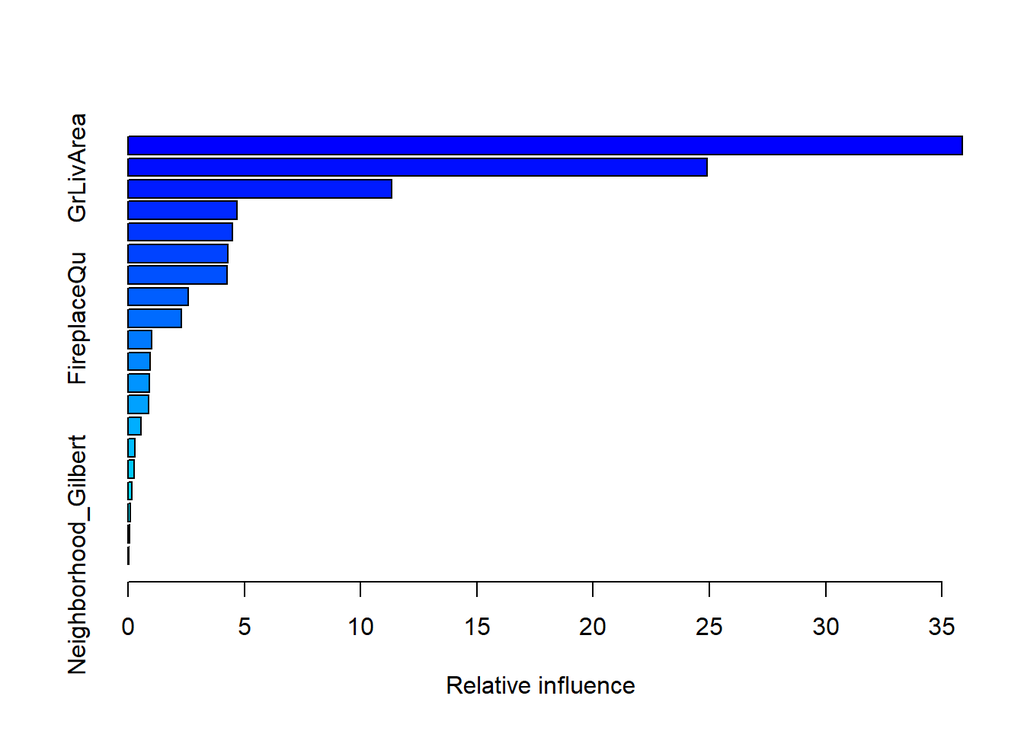

```
##                                       var     rel.inf
## OverallQual                   OverallQual 35.86575260
## GrLivArea                       GrLivArea 24.88354759
## GarageArea                     GarageArea 11.32052924
## MasVnrArea                     MasVnrArea  4.68159459
## WoodDeckSF                     WoodDeckSF  4.49614964
## KitchenQual                   KitchenQual  4.30742988
## ExterQual                       ExterQual  4.26643736
## FullBath                         FullBath  2.59271554
## FireplaceQu                   FireplaceQu  2.28545882
## Neighborhood_Crawfor Neighborhood_Crawfor  1.02130010
## SaleType_New                 SaleType_New  0.96591023
## LotShape                         LotShape  0.93068962
## Neighborhood_NoRidge Neighborhood_NoRidge  0.89383240
## Neighborhood_NridgHt Neighborhood_NridgHt  0.56979664
## Neighborhood_StoneBr Neighborhood_StoneBr  0.29840199
## Condition1_Artery       Condition1_Artery  0.25448714
## LandContour_HLS           LandContour_HLS  0.16549025
## Neighborhood_CollgCr Neighborhood_CollgCr  0.10248368
## Neighborhood_Timber   Neighborhood_Timber  0.06975641
## Neighborhood_Gilbert Neighborhood_Gilbert  0.02823627
```

```r
# Set up boosting model
boost.overall = gbm(SalePrice~., data = dfOverall[train.overall,],
                    distribution = "gaussian", # continuous
                    n.trees = 10000, shrinkage = 0.01, interaction.depth = 4)
# Show variable importance plot
summary(boost.overall)
```

Our model here is largely influenced by only a handful of variables: `OverallQual` accounting for about a third, `GrLivArea` about a fourth, followed by `GarageArea` and then some others. Let’s look at a few of them:

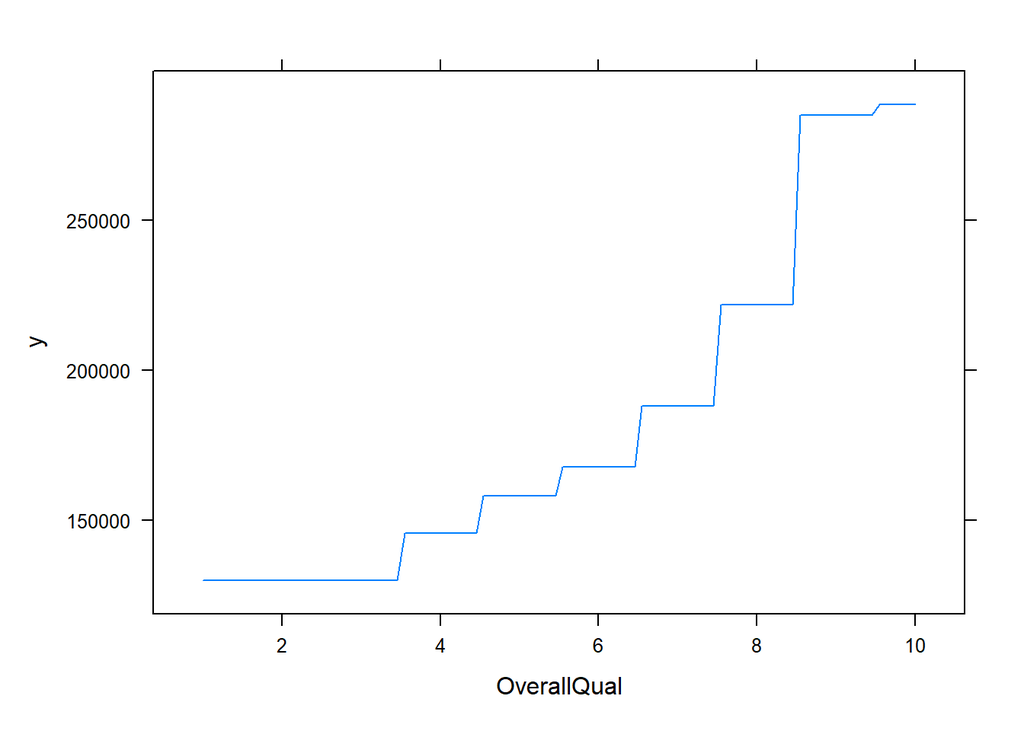

```r
# Plot variables
plot(boost.overall,i="OverallQual")
```

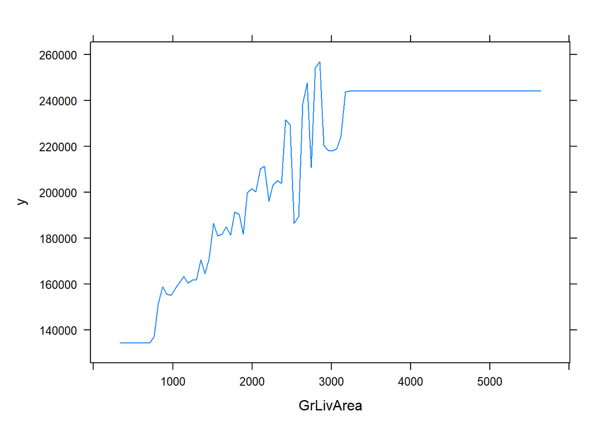

```r
plot(boost.overall,i="GrLivArea")
```

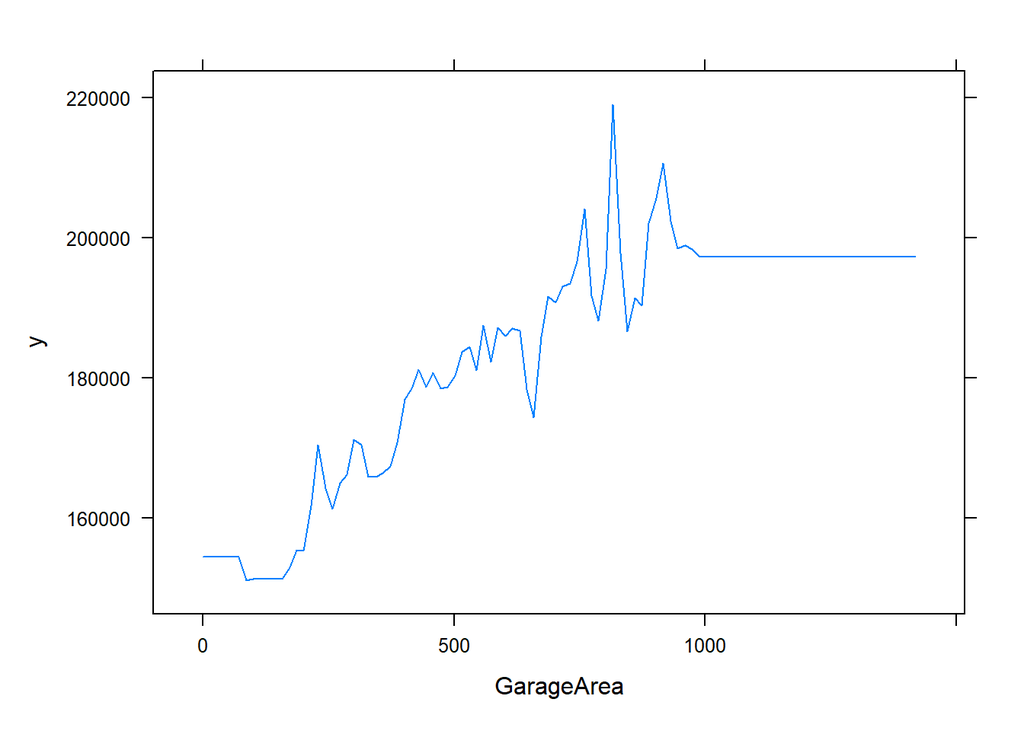

```r
plot(boost.overall,i="GarageArea")
```

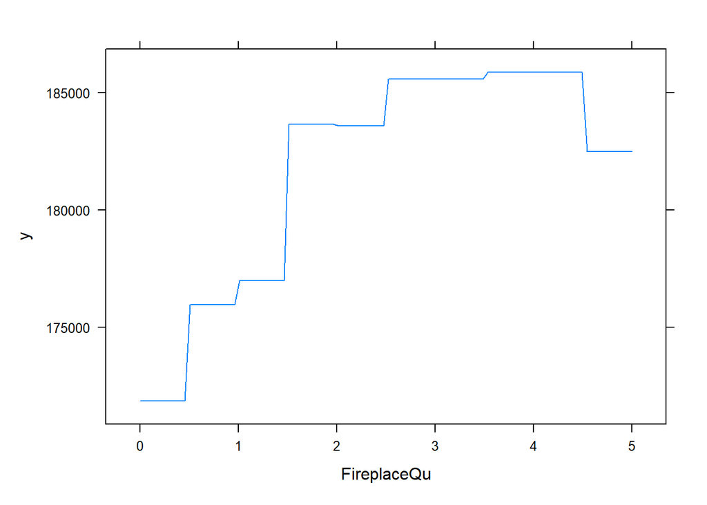

```r
plot(boost.overall,i="FireplaceQu")
```

Most of these variables appear to show a roughly linear increase in correlation with `SalePrice`, but notice that `FirePlaceQu` has a huge jump between 0/1 rating compared to 2+ rating. In the future, this variable could probably be binned into a binary good/bad rating.

### Predict the boosted model on the data set

```r
# Make a grid of number of trees
n.trees = seq(from = 100, to = 10000, by = 100)
# Run predict on boosted model
predmat = predict(boost.overall, newdata = dfOverall[-train.overall,], n.trees = n.trees)
# dim(predmat)

# Compute the test error
boost.err = with(dfOverall[-train.overall,],
                 apply( (predmat - SalePrice)^2, 2, mean) )

# Best error from random forest
print("Random forest best error:")
```

```
## [1] "Random forest best error:"
```

```r
min(test.err)
```

```
## [1] 931005084
```

```r
# Best error from boosting
print("Boosting best error:")
```

```
## [1] "Boosting best error:"
```

```r
min(boost.err)
```

```
## [1] 1018108266
```

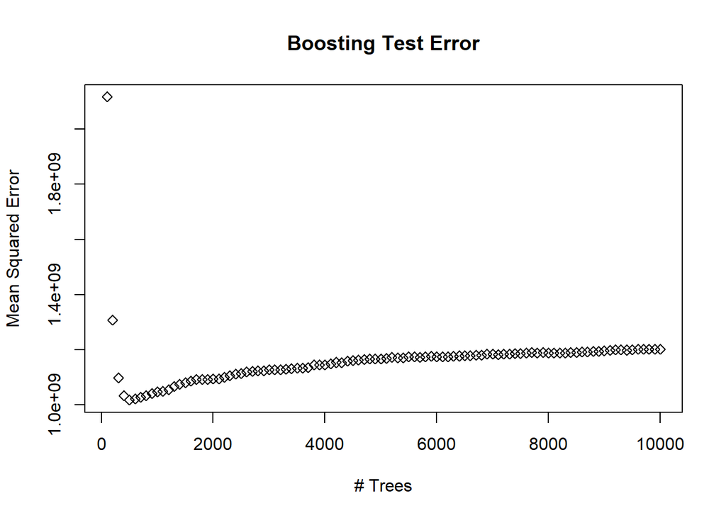

```r
# Plot results
plot(n.trees, boost.err, pch = 23, ylab = "Mean Squared Error",
     xlab = "# Trees", main = "Boosting Test Error")
abline(h = min(test.err), col = "red")
```

# Ensemble Modeling

Using `SuperLearner()`  
Sources:  
* [Ensembles](https://www.datacamp.com/community/tutorials/ensemble-r-machine-learning) * [SuperLearner](https://cran.r-project.org/web/packages/SuperLearner/vignettes/Guide-to-SuperLearner.html)

```r
# Load libraries
library("SuperLearner")
# Split data
train_idx <- sample(nrow(dfOverall), 2/3 * nrow(dfOverall))
df_train <- dfOverall[train_idx,]
df_test <- dfOverall[-train_idx,]

# Spilt out target variable
y <- df_train[,1]
ytest <- df_test[,1]

# Split out predictor variables
x <- df_train[,2:21]
xtest <- df_test[,2:21]

# Return the model
sl <- SuperLearner(y, x, family = gaussian(), # gaussian for continuous var
                   SL.library = list("SL.speedlm", "SL.svm", "SL.gbm",
                                     "SL.extraTrees"))
# # Models removed from ensemble due to low coefficient:
# list("SL.bayesglm", "SL.nnet", "SL.speedglm", "SL.caret.rpart", "SL.glmnet",
#      "SL.randomForest", "SL.biglasso", "SL.ranger", "SL.step.forward",
#      "SL.earth", "SL.ipredbagg", "SL.polymars", "SL.step", "SL.rpart",
#      "SL.cforest", "SL.ksvm", "SL.stepAIC",  # removed first pass
#      "SL.xgboost", "SL.bartMachine",         # removed second pass
#      "SL.rpartPrune",                        # removed third pass
#      "SL.loess")                             # removed due to high added risk

# Return the model
sl
```

```
##
## Call:
## SuperLearner(Y = y, X = x, family = gaussian(), SL.library = list("SL.speedlm",
##     "SL.svm", "SL.gbm", "SL.extraTrees"))
##
##
##                         Risk       Coef
## SL.speedlm_All    1218018435 0.03312668
## SL.svm_All        1345225758 0.00000000
## SL.gbm_All        1079661265 0.22596426
## SL.extraTrees_All  961350826 0.74090906
```

```r
# Look at modeling time
sl$times
```

```
## $everything
##    user  system elapsed
##   69.00    2.30  219.53
##
## $train
##    user  system elapsed
##   62.05    2.03  194.67
##
## $predict
##    user  system elapsed
##    6.92    0.25   24.81
```

The `extraTrees` model in the ensemble has the highest coefficient, indicating it is weighted highly in the ensemble. Following this, `speedlm` and `gbm` are the next highest weighted models.

### Cross-Validation of Ensemble

```r
# Get V-fold cross-validated risk estimate
cv.sl <- CV.SuperLearner(y, x, V=5, family = gaussian(), # gaussian for continuous var
                         SL.library = list("SL.speedlm", "SL.svm", "SL.gbm",
                                           "SL.extraTrees"))

# Print out the summary statistics
summary(cv.sl)
```

```
##
## Call:
## CV.SuperLearner(Y = y, X = x, V = 5, family = gaussian(), SL.library = list("SL.speedlm",
##     "SL.svm", "SL.gbm", "SL.extraTrees"))
##
## Risk is based on: Mean Squared Error
##
## All risk estimates are based on V =  5
##
##          Algorithm        Ave        se        Min        Max
##      Super Learner  979975551 128565247  789714974 1128506169
##        Discrete SL 1030291263 139552965  804413388 1278157563
##     SL.speedlm_All 1209014118 192572856  893045002 1637594877
##         SL.svm_All 1346287861 196954958 1046428644 1675688164
##         SL.gbm_All 1094135877 153756276  883230864 1278157563
##  SL.extraTrees_All  966862850 108139267  804413388 1162016496
```

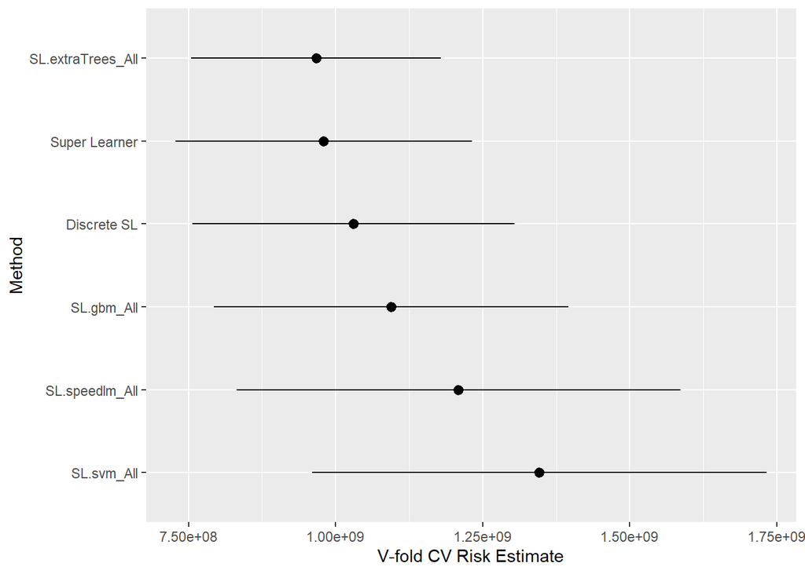

```r
# Plot models used and their variation
plot(cv.sl)
```

### Make Predictions using `SuperLearner()`

```r
# Make Predictions with SuperLearner
predictions <- predict.SuperLearner(sl, newdata=xtest)

# Return ensemble predictions
head(predictions$pred)
```

```
##          [,1]
## [1,] 221304.1
## [2,] 142056.0
## [3,] 255537.7
## [4,] 233451.1
## [5,] 150763.8
## [6,] 123719.6
```

```r
# Return individual library predictions
head(predictions$library.predict)
```

```
##      SL.speedlm_All SL.svm_All SL.gbm_All SL.extraTrees_All
## [1,]       228065.9   229015.7   220088.1          221372.6
## [2,]       135858.8   140943.2   138448.6          143433.3
## [3,]       236993.9   238636.8   255762.0          256298.4
## [4,]       255318.9   238410.4   233249.9          232534.8
## [5,]       148896.7   151304.6   141489.5          153675.8
## [6,]       118590.9   124604.0   122322.5          124375.0
```

### Predict using test data set

```r
# Predict back on the holdout data set
# Note: onlySL=TRUE includes only models weighted > 0
pred = predict(sl, xtest, onlySL = TRUE)

# Check the structure of this prediction object.
str(pred)
```

```
## List of 2
##  $ pred           : num [1:487, 1] 221304 142056 255538 233451 150764 ...
##  $ library.predict: num [1:487, 1:4] 228066 135859 236994 255319 148897 ...
```

```r
# Review the columns of $library.predict.
summary(pred$library.predict)
```

```
##        V1               V2          V3               V4
##  Min.   : 31614   Min.   :0   Min.   : 75129   Min.   : 59654
##  1st Qu.:128223   1st Qu.:0   1st Qu.:130911   1st Qu.:131610
##  Median :171385   Median :0   Median :165285   Median :167255
##  Mean   :182198   Mean   :0   Mean   :181381   Mean   :181115
##  3rd Qu.:218870   3rd Qu.:0   3rd Qu.:211544   3rd Qu.:211925
##  Max.   :469715   Max.   :0   Max.   :470161   Max.   :444716
```

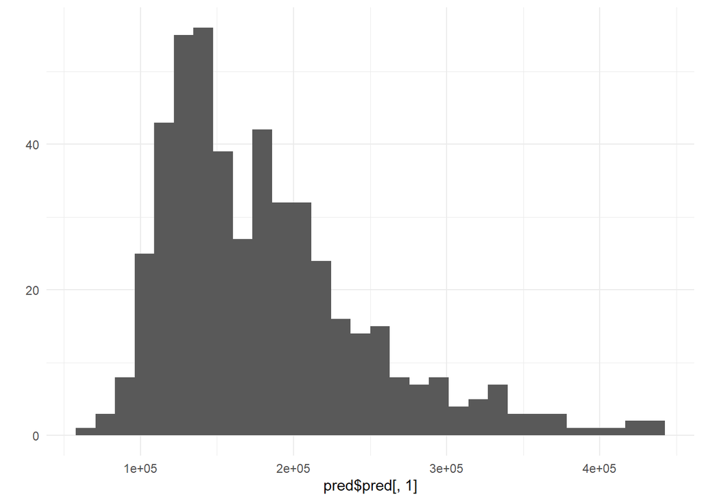

```r
# Histogram of our predicted values.
library(ggplot2)
qplot(pred$pred[, 1]) + theme_minimal()
```

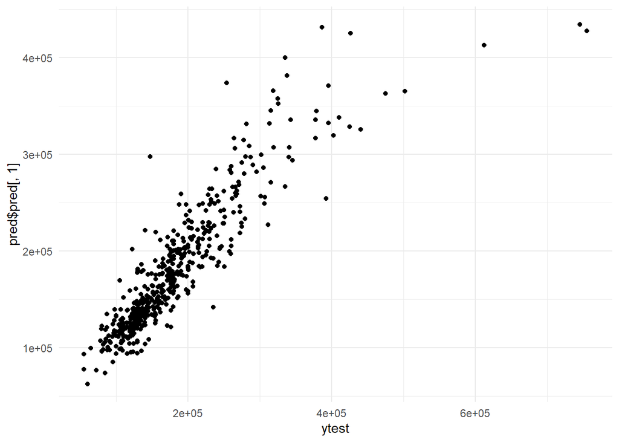

```r
# Scatterplot of original values (0, 1) and predicted values.
qplot(ytest, pred$pred[, 1]) + theme_minimal()
```

Note: there’s some hyperparameter tuning available in SuperLearner as well.